# MLFS method with regression

Same as the method for classification, but now suppose we have $N$ data points, each having a univariate continuous response $y_i \in {\mathbb{R}}$ (instead of a label).

# Testing MLFS method on simulated data

Generate two views, both with 10 features. Altogether 200 data points (100 for training, 100 for testing).

We will consider three scenarios

- Two Gaussian views
- One gaussian, one ordinal (with 3 levels)
- Both ordinal views (both with 3 levels)

That is, data was generated as follows:

Performance reported as $R^2$.

### Sanity check

Perfect scenario (data generated exactly according to the model).

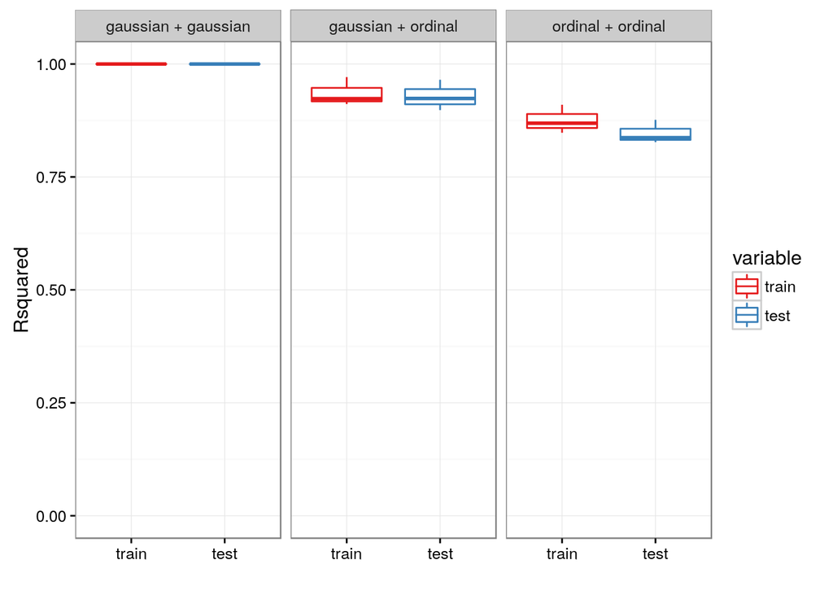

### How fast does variational Bayes converge?

(skipped at the moment)

### What if we increase the amount of noise

Lets increase the noise in generating ${\mathbf{U}}$, i.e. explore behaviour w.r.t. $\gamma$ in equation ${\mathbf{U}}_i^{(m)} \sim {\mathcal{N}}({\mathbf{V}}_i {\mathbf{W}}^{(m)}, \frac{1}{\gamma_m} {\mathbf{I}})$.

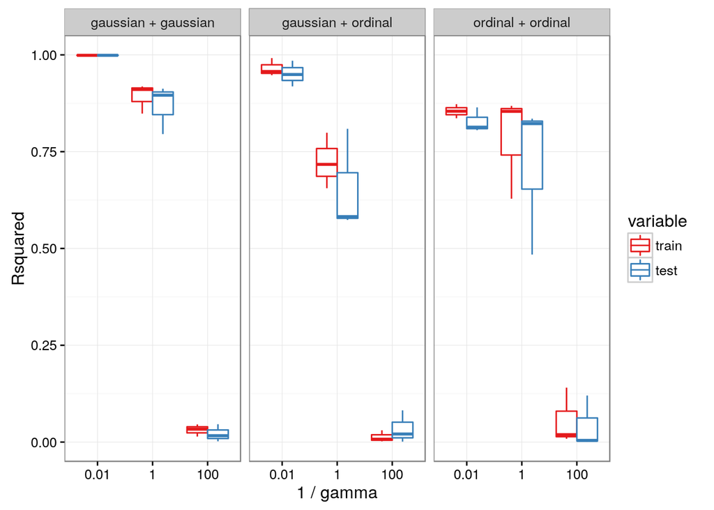

### Can the model (ARD prior) handle large number of irrelevant features?

Each view has (10 + irrelevant) features now

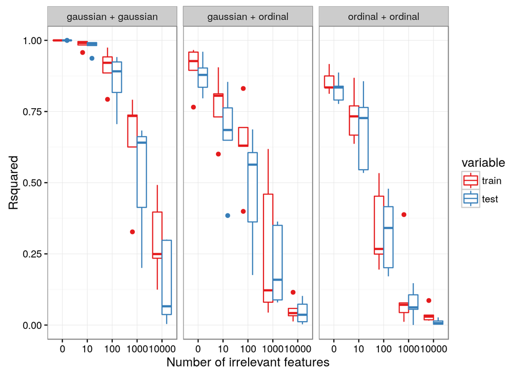

### What if the dimensionality of latent space is misspecified?

In the generated data, the underlying latent space was 6-dimensional. When fitting the model, lets consider misspecified values $\{2, 4 < 6 < 10, 20\}$.

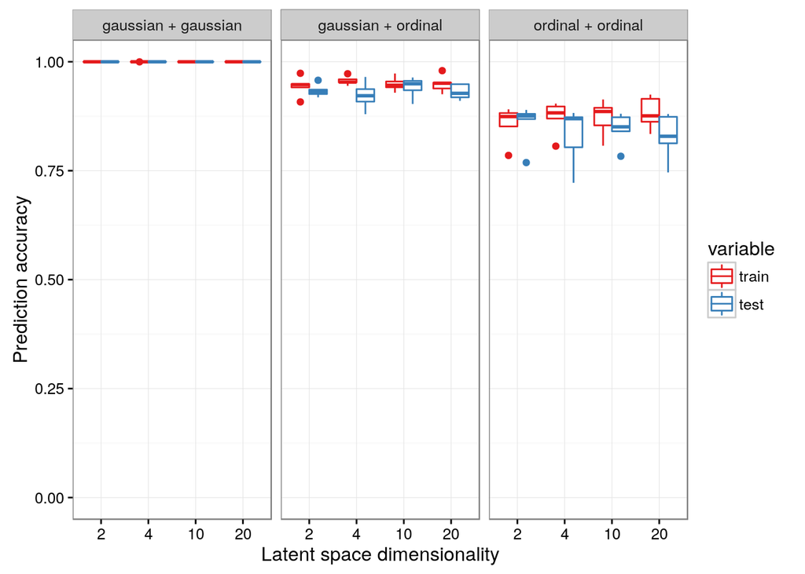

### What if there are multiple correlated features?

To generate a scenario where there are multiple correlated features, for example

1. One way would be to generate ${\mathbf{U}}$ from ${\mathbf{V}}$ and ${\mathbf{W}}$ as usual, and then modify ${\mathbf{U}}$ by taking its columns and adding new correlated ones
2. Another way would be to create correlated columns in ${\mathbf{W}}$ (i.e. deviate from the assumption that the elements within the row of ${\mathbf{W}}$ are uncorrelated)

Lets start with approach 2. Having constructed original ${\mathbf{W}}^{(m)}$, add $\{1, 5, 10\}$ correlated copies of its columns (correlation with original feature around 0.8).

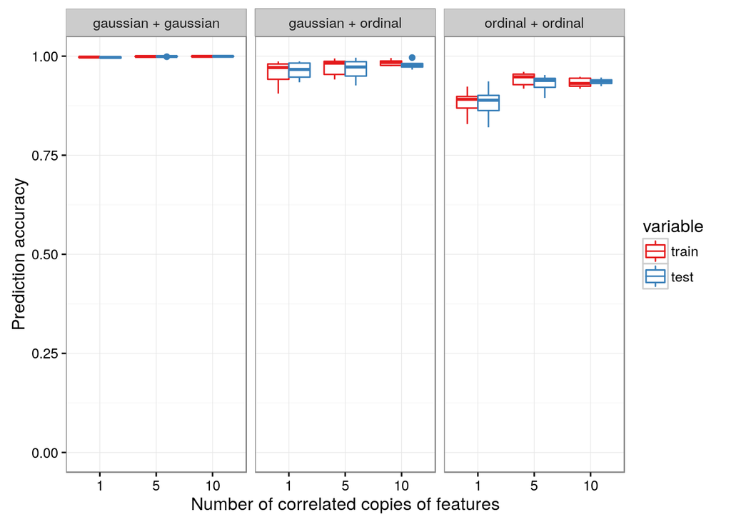

### What if the Gaussianity assumption is violated?

In principle, we could also ask a similar question about Gaussianity in ${\mathbf{V}}$ or ${\mathbf{W}}$, but currently skip this.

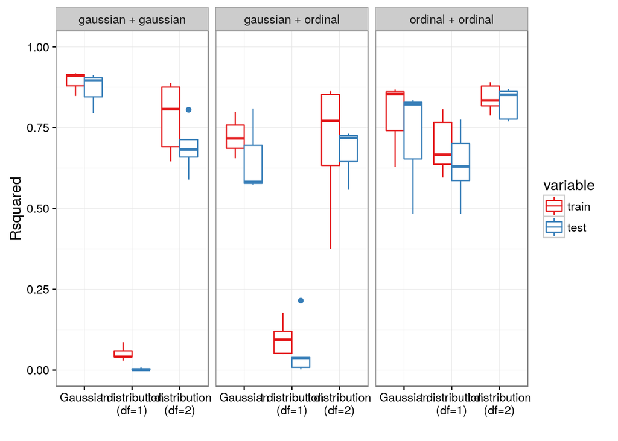

Quite a large drop in performance.

But what if we apply a **rank-based inverse-normal transformation** to the (Gaussian) features before using our method.

Example of “before” and “after normalisation”

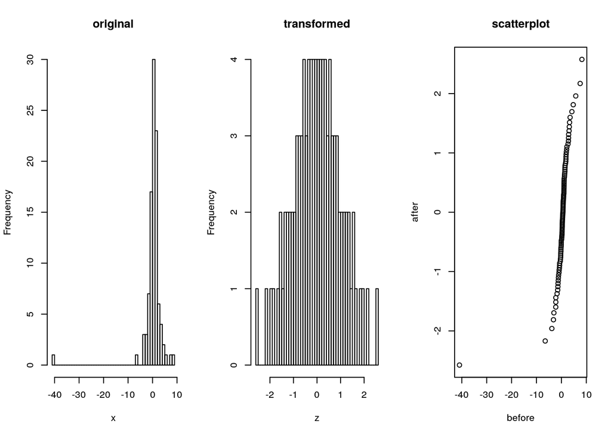

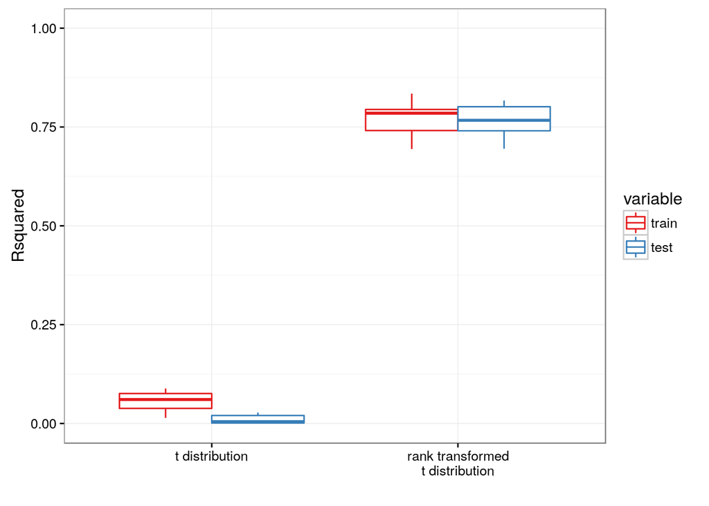

Improved performance!

### What if some of the views have been mislabelled?

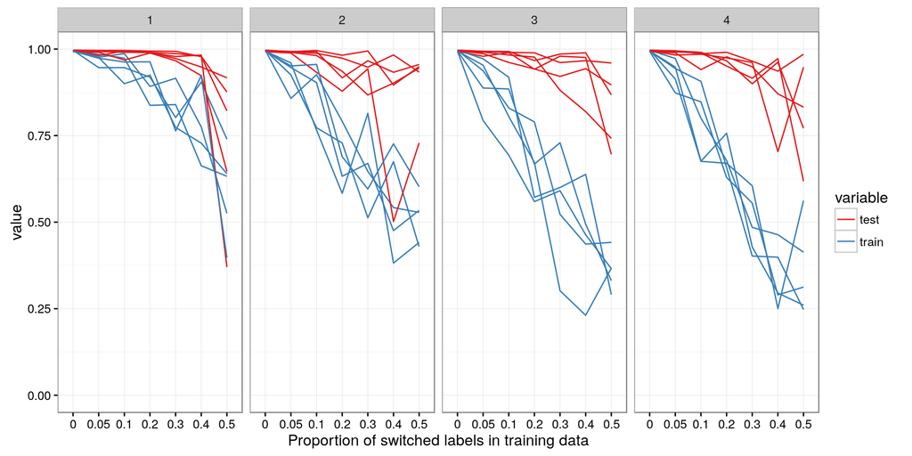